# When Every Row Becomes a Curve: Using Andrews Transforms to Turn Multivariate Wine Data into Actionable Quality Intelligence

Outlier detection, clustering, hypothesis testing, and process monitoring — all from curves that preserve every relationship in your data

Author

Simon Müller

```r
library(fdars)
library(ggplot2)
library(dplyr)
library(patchwork)
library(knitr)
theme_set(theme_minimal(base_size = 13))
set.seed(42)
```

## The Problem with Tables

A quality-control analyst at a winery sits down to review the latest batch of 178 wines. Each sample has been tested for 13 chemical properties — alcohol content, malic acid, ash, alkalinity, magnesium, phenols, flavanoids, nonflavanoid phenols, proanthocyanins, color intensity, hue, OD280/OD315 dilution ratio, and proline. That’s 178 × 13 = **2,314 numbers**. The analyst needs to answer simple questions: *Are there any anomalous wines? Do the three cultivars (Barolo, Grignolino, Barbera) look chemically distinct? Which chemicals matter most for telling them apart?*

Behind these questions sits a business reality. The winery needs to:

1. **Detect production anomalies** before a defective batch ships. A single mislabeled or adulterated wine can trigger a recall.
2. **Validate cultivar identity** for denomination-of-origin certification. The regulator wants proof, not assertions.
3. **Reduce testing costs** by identifying which of the 13 assays are truly necessary and which are redundant.
4. **Establish ongoing monitoring** so that *future* batches can be checked against a validated reference profile — not re-analyzed from scratch every time.

Standard practice tackles these one at a time: a spreadsheet for anomaly screening, a MANOVA for group differences, a PCA for variable reduction, a separate set of per-variable control charts for monitoring. Each tool uses its own distance metric, its own assumptions, and its own output format. Nothing connects them.

This article demonstrates a different approach: **transform the 13 chemical measurements into Andrews curves**, and then apply a unified pipeline of functional data analysis (FDA) methods. Each step delivers a concrete business outcome:

| Step | Method | Business Outcome |
| --- | --- | --- |
| Visualize | Andrews curves | See each wine as a single chemical fingerprint |
| Detect | Depth, outliergram, MS-plot | Triage anomalies by *type* (magnitude, shape, mislabel) |
| Validate | Clustering, permutation test | Prove cultivars are chemically distinct (p-value) |
| Optimize | FPCA, variable importance | Identify which 5 of 13 chemicals to keep testing |
| Monitor | Functional boxplot, tolerance bands | Check new batches against a validated specification |

The key guarantee: Andrews curves preserve Euclidean distances exactly (up to a constant $\sqrt{\pi}$), so every conclusion translates back to the original chemical units. Nothing is lost in the transformation.

Let’s start with the data and see why a spreadsheet isn’t enough.

```r
# UCI Wine dataset: 178 wines, 3 cultivars, 13 chemical measurements
wine_url <- "https://archive.ics.uci.edu/ml/machine-learning-databases/wine/wine.data"
col_names <- c("Cultivar", "Alcohol", "MalicAcid", "Ash", "Alkalinity",
               "Magnesium", "Phenols", "Flavanoids", "NonflavPhenols",
               "Proanthocyanins", "ColorIntensity", "Hue",
               "OD280_OD315", "Proline")
wine <- read.csv(wine_url, header = FALSE, col.names = col_names)

# Use real cultivar names
cultivar <- factor(wine$Cultivar,
                   levels = 1:3,
                   labels = c("Barolo", "Grignolino", "Barbera"))

# Standardize the 13 chemical variables
X <- scale(as.matrix(wine[, -1]))
chem_names <- colnames(wine)[-1]

cat(nrow(wine), "wines,", ncol(X), "chemicals,",
    nlevels(cultivar), "cultivars\n")
```

```
178 wines, 13 chemicals, 3 cultivars
```

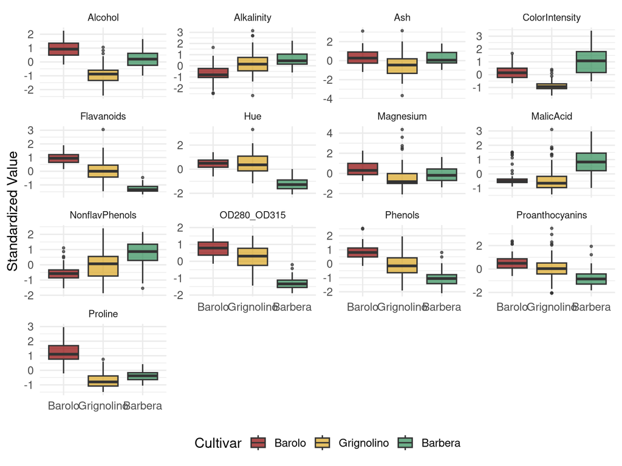

Standardized chemical profiles by cultivar — some variables separate groups, most overlap.

```r
df_box <- data.frame(X) |>
  mutate(Cultivar = cultivar) |>
  tidyr::pivot_longer(-Cultivar, names_to = "Chemical", values_to = "Value")

ggplot(df_box, aes(x = Cultivar, y = Value, fill = Cultivar)) +
  geom_boxplot(alpha = 0.7, outlier.size = 0.8) +
  facet_wrap(~ Chemical, scales = "free_y", ncol = 4) +
  scale_fill_manual(values = c("Barolo" = "#8B0000",
                                "Grignolino" = "#DAA520",
                                "Barbera" = "#2E8B57")) +
  labs(x = NULL, y = "Standardized Value") +
  theme(legend.position = "bottom",
        strip.text = element_text(size = 9))
```

Some variables (Flavanoids, Proline, Color Intensity) clearly separate cultivars. Others (Ash, Magnesium) overlap heavily. But you can’t *see a wine* here — you see 13 disconnected box-and-whisker slices. Every decision about blending, pricing, or fraud detection requires a **holistic view** of each wine’s chemical fingerprint. That’s where Andrews curves come in.

## Turning Rows into Curves

The **Andrews transformation** (Andrews, 1972) maps each $p$-dimensional observation $\mathbf{x} = (x_1, \ldots, x_p)$ to a curve on $[-\pi, \pi]$ using a Fourier expansion:

$$f_{\mathbf{x}}(t) = \frac{x_1}{\sqrt{2}} + x_2\sin(t) + x_3\cos(t) + x_4\sin(2t) + x_5\cos(2t) + \cdots$$

The key guarantee: **$L^2$ distance between curves equals $\sqrt{\pi}$ times the Euclidean distance between the original vectors.** Nothing is lost. Nothing is distorted.

```r
andrews_transform <- function(X, m = 200) {
  if (is.data.frame(X)) X <- as.matrix(X)
  n <- nrow(X)
  p <- ncol(X)
  t_grid <- seq(-pi, pi, length.out = m)

  # Build Fourier basis matrix [m x p]
  basis <- matrix(0, m, p)
  basis[, 1] <- 1 / sqrt(2)
  for (j in 2:p) {
    k <- ceiling((j - 1) / 2)
    if (j %% 2 == 0) {
      basis[, j] <- sin(k * t_grid)
    } else {
      basis[, j] <- cos(k * t_grid)
    }
  }

  fdata(X %*% t(basis), argvals = t_grid)
}

fd_wine <- andrews_transform(X)
cat("Andrews curves:", nrow(fd_wine$data), "observations,",
    ncol(fd_wine$data), "grid points\n")
```

```
Andrews curves: 178 observations, 200 grid points
```

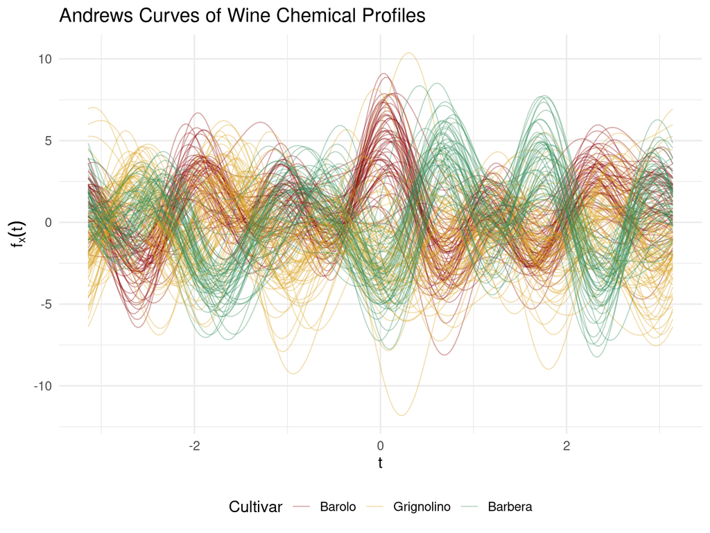

178 wines as Andrews curves — each curve is a chemical fingerprint. Cultivar separation is immediately visible.

```r
n <- nrow(fd_wine$data)
m <- ncol(fd_wine$data)
t_grid <- fd_wine$argvals

df_curves <- data.frame(
  t = rep(t_grid, n),
  value = as.vector(t(fd_wine$data)),
  curve = rep(1:n, each = m),
  Cultivar = rep(cultivar, each = m)
)

ggplot(df_curves, aes(x = t, y = value, group = curve, color = Cultivar)) +
  geom_line(alpha = 0.35, linewidth = 0.4) +
  scale_color_manual(values = c("Barolo" = "#8B0000",
                                 "Grignolino" = "#DAA520",
                                 "Barbera" = "#2E8B57")) +
  labs(title = "Andrews Curves of Wine Chemical Profiles",
       x = expression(t), y = expression(f[x](t))) +
  theme(legend.position = "bottom")
```

Now each wine has a **signature** — a single visual object that encodes all 13 measurements. A quality manager can glance at a curve and compare it to the cultivar’s typical profile. Wines that “look different” are immediately suspicious. This is the multivariate equivalent of a chromatography trace — one picture captures the whole chemical identity.

## Proving the Bridge Works

Pretty pictures are nice, but for regulatory or audit contexts, we need a **mathematical guarantee**. The Andrews distance preservation theorem says:

$$\|f_{\mathbf{x}} - f_{\mathbf{y}}\|_{L^2} = \sqrt{\pi} \cdot \|\mathbf{x} - \mathbf{y}\|_2$$

Let’s verify this on all $\binom{178}{2} = 15{,}753$ pairwise distances.

```r
# Compute pairwise distances in both domains
dist_andrews <- metric.lp(fd_wine)
dist_euclid <- as.matrix(dist(X))

# Extract upper triangle
idx_upper <- upper.tri(dist_andrews)
d_a <- dist_andrews[idx_upper]
d_e <- dist_euclid[idx_upper]

# Filter zero-distance pairs (if any duplicates)
nonzero <- d_e > 1e-10
ratio <- d_a[nonzero] / d_e[nonzero]

cat(sprintf("Distance ratio (Andrews / Euclidean):\n"))
```

```
Distance ratio (Andrews / Euclidean):
```

```r
cat(sprintf("  Mean:     %.4f\n", mean(ratio)))
```

```
  Mean:     1.7725
```

```r
cat(sprintf("  Median:   %.4f\n", median(ratio)))
```

```
  Median:   1.7725
```

```r
cat(sprintf("  SD:       %.2e\n", sd(ratio)))
```

```
  SD:       4.01e-16
```

```r
cat(sprintf("  sqrt(pi): %.4f\n", sqrt(pi)))
```

```
  sqrt(pi): 1.7725
```

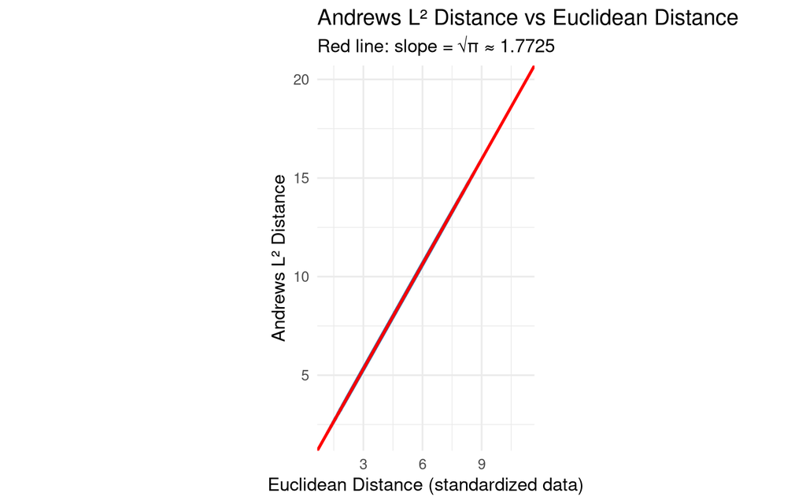

Every pairwise distance falls exactly on the √π line — the transformation is lossless.

```r
df_dist <- data.frame(euclidean = d_e[nonzero], andrews = d_a[nonzero])

ggplot(df_dist, aes(x = euclidean, y = andrews)) +
  geom_point(alpha = 0.08, size = 0.5, color = "steelblue") +
  geom_abline(slope = sqrt(pi), intercept = 0, color = "red", linewidth = 1) +
  labs(title = "Andrews L² Distance vs Euclidean Distance",
       subtitle = sprintf("Red line: slope = √π ≈ %.4f", sqrt(pi)),
       x = "Euclidean Distance (standardized data)",
       y = "Andrews L² Distance") +
  coord_equal()
```

The ratio is $\sqrt{\pi} \approx 1.7725$ to machine precision. Any conclusion drawn from the curves — outliers, clusters, similarities — translates *exactly* back to the original 13 chemical measurements. For regulatory or audit contexts, this mathematical proof is essential: you can report findings in chemical units, not abstract curve distances.

## Finding the Unusual Wines

In wine production, “unusual” can mean a quality problem, a labeling error, or outright fraud. A standard approach might flag individual chemicals that fall outside a reference range — but that misses wines whose *combination* of values is strange, even when no single measurement is extreme. Because Andrews curves encode *all 13 chemicals simultaneously*, outlier detection on curves catches multivariate anomalies that univariate checks miss.

We apply three complementary methods. Each asks a different question about “unusualness,” and each gives the quality controller a different kind of actionable insight.

### Method 1: Depth-Ponderation — “How far from the crowd?”

Think of *depth* as the opposite of outlyingness. The most “typical” wine — the one whose chemical profile sits squarely in the middle of the population — has the highest depth. Wines at the fringes have low depth. The depth-ponderation method (`outliers.depth.pond()`) stabilizes this measurement using **bootstrap resampling**: it repeatedly draws random subsets of the 178 wines, computes depth each time, and averages the results. This smoothing prevents a single unlucky sample from distorting the picture. Wines whose averaged depth falls below a threshold are flagged.

```r
set.seed(123)
out_pond <- outliers.depth.pond(fd_wine, nb = 500)
cat("Depth-ponderation outliers:", sort(out_pond$outliers), "\n")
```

```
Depth-ponderation outliers: 60 70 74 79 96 97 111 122 159
```

```r
cat("Cultivars:", as.character(cultivar[out_pond$outliers]), "\n")
```

```
Cultivars: Grignolino Grignolino Grignolino Grignolino Grignolino Grignolino Grignolino Grignolino Barbera
```

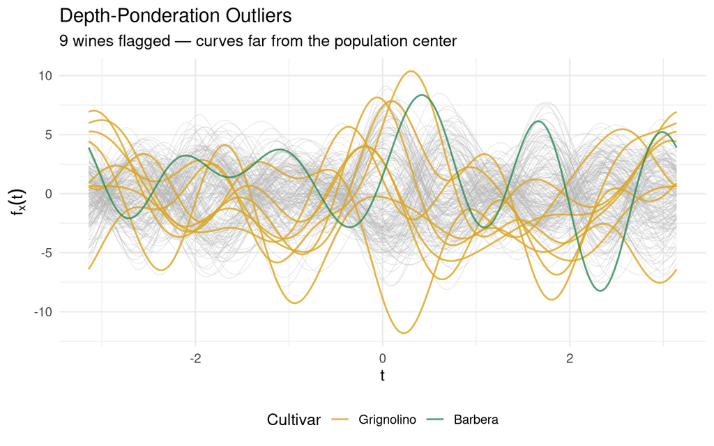

```r
is_pond_outlier <- rep(FALSE, n)
is_pond_outlier[out_pond$outliers] <- TRUE

ggplot() +
  geom_line(data = filter(df_curves, !rep(is_pond_outlier, each = m)),
            aes(x = t, y = value, group = curve),
            color = "gray70", alpha = 0.3, linewidth = 0.3) +
  geom_line(data = filter(df_curves, rep(is_pond_outlier, each = m)),
            aes(x = t, y = value, group = curve, color = Cultivar),
            linewidth = 0.7, alpha = 0.8) +
  scale_color_manual(values = c("Barolo" = "#8B0000", "Grignolino" = "#DAA520",
                                 "Barbera" = "#2E8B57")) +
  labs(title = "Depth-Ponderation Outliers",
       subtitle = sprintf("%d wines flagged — curves far from the population center",
                          length(out_pond$outliers)),
       x = expression(t), y = expression(f[x](t))) +
  theme(legend.position = "bottom")
```

What makes these wines unusual? Let’s look at which chemicals push them to the fringes:

```r
# For each flagged wine, identify chemicals with |z-score| > 2
extreme_list <- lapply(sort(out_pond$outliers), function(i) {
  extreme_idx <- which(abs(X[i, ]) > 2)
  if (length(extreme_idx) > 0) {
    chems <- paste(sprintf("%s (z=%.1f)", colnames(wine)[-1][extreme_idx],
                           X[i, extreme_idx]), collapse = ", ")
  } else {
    chems <- "no individual extreme — unusual *combination*"
  }
  data.frame(Wine = i, Cultivar = as.character(cultivar[i]),
             `Extreme Chemicals` = chems, check.names = FALSE)
})
kable(bind_rows(extreme_list),
      caption = "What makes each depth-ponderation outlier unusual (|z| > 2)")
```

What makes each depth-ponderation outlier unusual (|z| > 2)

| Wine | Cultivar | Extreme Chemicals |
| --- | --- | --- |
| 60 | Grignolino | Ash (z=-3.7), Alkalinity (z=-2.7), Proanthocyanins (z=-2.0) |
| 70 | Grignolino | Ash (z=-2.2), Magnesium (z=3.6) |
| 74 | Grignolino | Alkalinity (z=3.1), Magnesium (z=2.7) |
| 79 | Grignolino | Magnesium (z=2.5), Proanthocyanins (z=2.0) |
| 96 | Grignolino | Magnesium (z=4.4), Proanthocyanins (z=3.0) |
| 97 | Grignolino | Magnesium (z=2.4) |
| 111 | Grignolino | Proanthocyanins (z=3.5) |
| 122 | Grignolino | Ash (z=3.1), Alkalinity (z=2.7), Flavanoids (z=3.1) |
| 159 | Barbera | ColorIntensity (z=3.4) |

### Method 2: Magnitude-Shape Plot — “Unusual *how*?”

The depth-ponderation method tells you *that* a wine is unusual, but not *how*. The magnitude-shape decomposition (`magnitudeshape()`) splits outlyingness into two independent components:

- **Magnitude outlyingness (MO)** measures whether a wine’s curve is systematically shifted up or down relative to the median wine. In chemical terms: are *all* values consistently high or consistently low? A high MO suggests a global issue — perhaps a measurement calibration error, a different vintage mixed in, or dilution/concentration.
- **Variability outlyingness (VO)** measures whether the *shape* of a wine’s curve deviates from the population’s typical shape, regardless of its overall level. In chemical terms: are the *ratios* between chemicals unusual? A high VO suggests a process anomaly — perhaps a fermentation gone wrong, soil contamination, or blending with a different cultivar.

The method plots every wine in this two-dimensional (MO, VO) space and draws a $\chi^2$-based cutoff ellipse. Wines outside the ellipse are flagged.

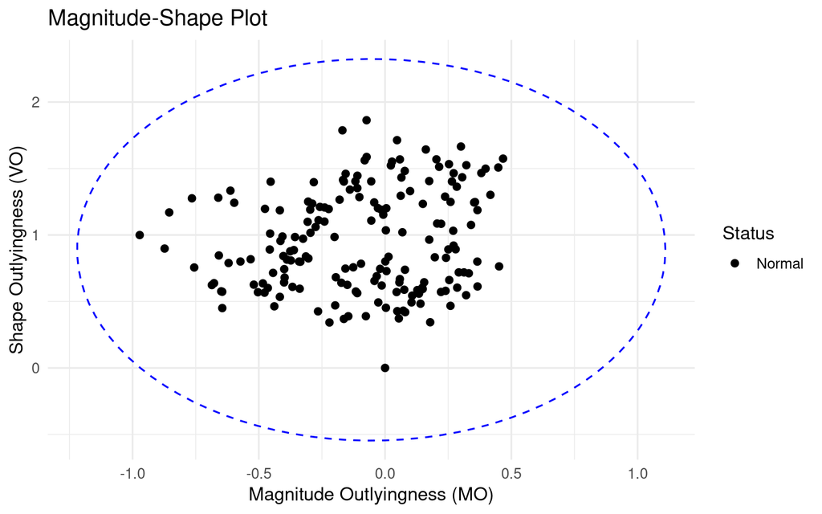

```r
ms <- magnitudeshape(fd_wine)
plot(ms)
```

With the default 99.3% cutoff, no wines are flagged here. This is informative, not disappointing — it tells us that the outliers found by depth-ponderation are **not extreme in the magnitude-shape sense**. They sit at the fringes of their cultivar group, but their chemical *ratios* are still within the normal range. For a quality controller, this is reassuring: these wines are unusual but not *suspiciously* unusual. If the MS-plot *did* flag a wine, that would be a stronger alarm — possibly indicating adulteration or a process failure that distorts the fundamental chemical fingerprint.

### Method 3: Outliergram — “Unusual in rank structure?”

The outliergram (`outliergram()`) takes a different angle entirely. It computes two rank-based statistics for each wine:

- **Modified Epigraph Index (MEI)**: what proportion of the time does this wine’s curve sit *above* other curves? A wine with MEI near 0.5 is average in its vertical position; a wine near 0 or 1 is persistently low or high.
- **Modified Band Depth (MBD)**: how often does this wine’s curve fall *within the band* formed by pairs of other curves? High MBD means the wine has a typical profile; low MBD means it tends to cross or escape the population envelope.

For a well-behaved population, MEI and MBD follow a tight parabolic relationship: wines that are vertically central (MEI ≈ 0.5) should also be deeply enclosed (high MBD). The outliergram flags wines that deviate from this expected relationship — wines whose MBD is *lower than expected* given their MEI. These are **shape outliers**: wines that weave in and out of the population bundle in an unusual way.

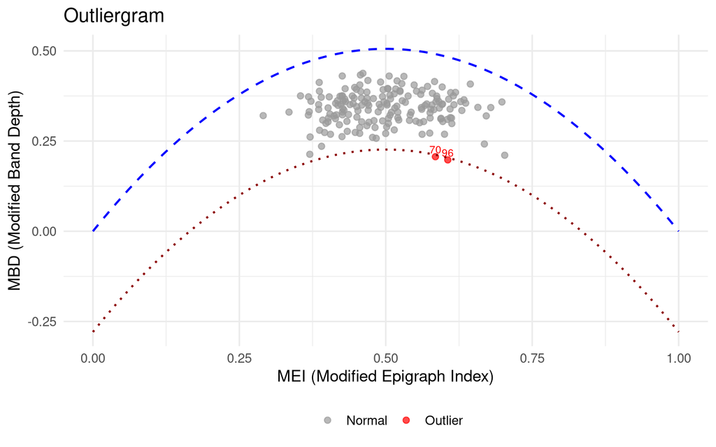

```r
og <- outliergram(fd_wine)
plot(og)
```

```r
if (length(og$outliers) > 0) {
  cat("Outliergram outliers:", sort(og$outliers), "\n")
  cat("Cultivars:", as.character(cultivar[og$outliers]), "\n")
  for (i in sort(og$outliers)) {
    extreme_idx <- which(abs(X[i, ]) > 2)
    if (length(extreme_idx) > 0) {
      cat(sprintf("  Wine %d: %s\n", i,
                  paste(sprintf("%s (z=%.1f)", colnames(wine)[-1][extreme_idx],
                                X[i, extreme_idx]), collapse = ", ")))
    }
  }
}
```

```
Outliergram outliers: 70 96
Cultivars: Grignolino Grignolino
  Wine 70: Ash (z=-2.2), Magnesium (z=3.6)
  Wine 96: Magnesium (z=4.4), Proanthocyanins (z=3.0)
```

The outliergram flags the most severe shape anomalies — wines whose internal chemical relationships are unusual even though their overall levels may be plausible. For a quality controller, a shape outlier warrants a different investigation than a magnitude outlier: you wouldn’t re-calibrate the instrument; you’d investigate the vineyard, the fermentation, or the supply chain.

### Cross-Referencing: The Confidence Triage

No single outlier detection method is perfect. Each trades off sensitivity against specificity, and each is blind to certain kinds of anomaly. The real power comes from **cross-referencing**: wines flagged by multiple methods are the highest-priority cases for investigation.

```r
# Collect flags per observation
outlier_flags <- data.frame(
  Wine = 1:n,
  Cultivar = cultivar,
  DepthPond = 1:n %in% out_pond$outliers,
  MagnShape = 1:n %in% ms$outliers,
  Outliergram = 1:n %in% og$outliers
)
outlier_flags$n_methods <- rowSums(outlier_flags[, 3:5])

# Show wines flagged by at least one method
flagged <- outlier_flags |> filter(n_methods >= 1) |> arrange(desc(n_methods))

cat(nrow(flagged), "wines flagged by at least one method,",
    sum(flagged$n_methods >= 2), "by two or more\n\n")
```

```
9 wines flagged by at least one method, 2 by two or more
```

```r
# Show flagged wines with their original chemical values
flagged_detail <- flagged |>
  mutate(across(c(DepthPond, MagnShape, Outliergram),
                ~ ifelse(., "✓", ""))) |>
  left_join(
    data.frame(Wine = 1:n, round(wine[, -1], 1)),
    by = "Wine"
  )

kable(flagged_detail |> select(Wine, Cultivar, DepthPond, MagnShape,
                                Outliergram, n_methods,
                                Alcohol, Flavanoids, ColorIntensity, Proline),
      caption = "Flagged wines with key chemical values")
```

Flagged wines with key chemical values

| Wine | Cultivar | DepthPond | MagnShape | Outliergram | n_methods | Alcohol | Flavanoids | ColorIntensity | Proline |
| --- | --- | --- | --- | --- | --- | --- | --- | --- | --- |
| 70 | Grignolino | ✓ |  | ✓ | 2 | 12.2 | 1.3 | 2.9 | 718 |
| 96 | Grignolino | ✓ |  | ✓ | 2 | 12.5 | 2.3 | 2.6 | 937 |
| 60 | Grignolino | ✓ |  |  | 1 | 12.4 | 0.6 | 2.0 | 520 |
| 74 | Grignolino | ✓ |  |  | 1 | 13.0 | 2.9 | 3.4 | 985 |
| 79 | Grignolino | ✓ |  |  | 1 | 12.3 | 1.9 | 3.4 | 750 |
| 97 | Grignolino | ✓ |  |  | 1 | 11.8 | 1.0 | 2.5 | 625 |
| 111 | Grignolino | ✓ |  |  | 1 | 11.5 | 2.6 | 2.9 | 562 |
| 122 | Grignolino | ✓ |  |  | 1 | 11.6 | 5.1 | 6.0 | 465 |
| 159 | Barbera | ✓ |  |  | 1 | 14.3 | 1.3 | 13.0 | 660 |

### Deep Dive: The Grignolino Problem

Before we reach for generic conclusions, let’s look at the data. Eight of nine outliers are Grignolino — zero from Barolo, one from Barbera. That asymmetry is itself an important finding. Let’s understand what’s driving it.

```r
fda_all_idx <- unique(c(out_pond$outliers, og$outliers, ms$outliers))

cat("Outliers by cultivar:\n")
```

```
Outliers by cultivar:
```

```r
for (cv in levels(cultivar)) {
  cv_n <- sum(cultivar == cv)
  cv_out <- sum(cultivar[fda_all_idx] == cv)
  cat(sprintf("  %s: %d outliers out of %d wines (%.0f%%)\n",
              cv, cv_out, cv_n, 100 * cv_out / cv_n))
}
```

```
  Barolo: 0 outliers out of 59 wines (0%)
  Grignolino: 8 outliers out of 71 wines (11%)
  Barbera: 1 outliers out of 48 wines (2%)
```

Grignolino has by far the most variable chemical profile. Why? Let’s examine what the flagged wines have in common. For each outlier, we compute its deviation from its own cultivar mean (in within-cultivar standard deviations) — this tells us how unusual a wine is *relative to its peer group*, not just globally:

```r
# Compute within-cultivar z-scores for each outlier
outlier_profiles <- lapply(sort(fda_all_idx), function(i) {
  cv <- cultivar[i]
  cv_idx <- which(cultivar == cv)
  cv_mean <- colMeans(wine[cv_idx, -1])
  cv_sd <- apply(wine[cv_idx, -1], 2, sd)
  dev <- (as.numeric(wine[i, -1]) - cv_mean) / cv_sd
  names(dev) <- chem_names

  # Flag chemicals deviating > 1.5 within-cultivar SDs
  extreme <- which(abs(dev) > 1.5)
  data.frame(
    Wine = i,
    Cultivar = as.character(cv),
    `Extreme Chemicals (> 1.5 cultivar SD)` =
      if (length(extreme) > 0)
        paste(sprintf("%s (%+.1f)", chem_names[extreme], dev[extreme]),
              collapse = ", ")
      else "none",
    n_extreme = length(extreme),
    check.names = FALSE
  )
})

kable(bind_rows(outlier_profiles),
      caption = "Each outlier's unusual chemicals, measured against its own cultivar")
```

Each outlier’s unusual chemicals, measured against its own cultivar

| Wine | Cultivar | Extreme Chemicals (> 1.5 cultivar SD) | n_extreme |
| --- | --- | --- | --- |
| 60 | Grignolino | Ash (-2.8), Alkalinity (-2.9), Flavanoids (-2.1), Proanthocyanins (-2.0), OD280_OD315 (-1.9) | 5 |
| 70 | Grignolino | Ash (-1.6), Magnesium (+3.4), NonflavPhenols (-1.8) | 3 |
| 74 | Grignolino | Alkalinity (+2.9), Magnesium (+2.7), Phenols (+1.9), Proline (+3.0) | 4 |
| 79 | Grignolino | Alkalinity (-1.6), Magnesium (+2.5), Proanthocyanins (+1.9) | 3 |
| 96 | Grignolino | Magnesium (+4.0), Proanthocyanins (+2.7), Proline (+2.7) | 3 |
| 97 | Grignolino | Ash (+1.6), Magnesium (+2.4), Flavanoids (-1.5), NonflavPhenols (-1.8) | 4 |
| 111 | Grignolino | Alcohol (-1.5), MalicAcid (+1.8), Phenols (+1.7), Proanthocyanins (+3.2), Hue (-1.5) | 5 |
| 122 | Grignolino | Ash (+3.1), Alkalinity (+2.5), Phenols (+1.7), Flavanoids (+4.2), ColorIntensity (+3.1), OD280_OD315 (+1.8) | 6 |
| 159 | Barbera | Alcohol (+2.2), MalicAcid (-1.5), Alkalinity (+1.6), Phenols (+3.1), Flavanoids (+1.8), Proanthocyanins (+3.8), ColorIntensity (+2.4) | 7 |

This is exactly the kind of systemic insight that a per-variable range check would bury. Yes, a spreadsheet filter could flag “Magnesium > 130,” but it wouldn’t reveal that these high-Magnesium wines *also* tend to have unusual Proanthocyanins, or that they cluster together in the Fourier domain. The curve representation lets us see the *compound pattern*.

### Case Study: Wine 122 — Mislabeled or Just Unusual?

Wine 122 is the most extreme outlier: it ranks dead last in depth among all 71 Grignolinos (rank 71/71). Let’s look at where it sits relative to all three cultivar groups:

```r
# Distance from Wine 122 to each cultivar median
case_wine <- 122

dist_to_median <- sapply(levels(cultivar), function(cv) {
  cv_idx <- which(cultivar == cv)
  fd_cv <- fd_wine[cv_idx]
  depths_cv <- depth.MBD(fd_cv)
  median_global <- cv_idx[which.max(depths_cv)]
  sqrt(sum((fd_wine$data[case_wine, ] - fd_wine$data[median_global, ])^2) *
       diff(fd_wine$argvals[1:2]))
})

cat(sprintf("Wine %d (%s) — distance to each cultivar median:\n", case_wine,
            cultivar[case_wine]))
```

```
Wine 122 (Grignolino) — distance to each cultivar median:
```

```r
for (cv in names(dist_to_median)) {
  marker <- ifelse(cv == as.character(cultivar[case_wine]), " <-- own cultivar", "")
  cat(sprintf("  %s: %.2f%s\n", cv, dist_to_median[cv], marker))
}
```

```
  Barolo: 10.67
  Grignolino: 12.65 <-- own cultivar
  Barbera: 13.24
```

```r
closest <- names(which.min(dist_to_median))
cat(sprintf("\nClosest to: %s\n", closest))
```

```
Closest to: Barolo
```

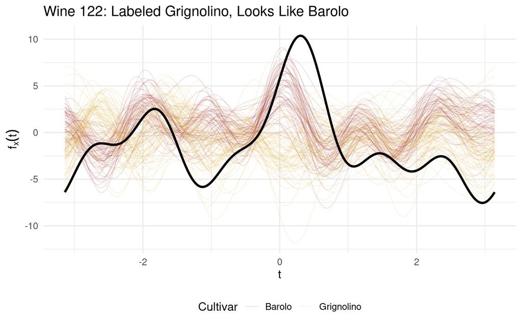

```r
# Highlight Wine 122 against its claimed cultivar and the cultivar it resembles
is_case <- rep(FALSE, n)
is_case[case_wine] <- TRUE

ggplot() +
  # Background: all curves, faded
  geom_line(data = filter(df_curves, Cultivar %in% c("Barolo", "Grignolino") &
                            !rep(is_case, each = m)),
            aes(x = t, y = value, group = curve, color = Cultivar),
            alpha = 0.15, linewidth = 0.3) +
  # Case wine: bold black
  geom_line(data = filter(df_curves, rep(is_case, each = m)),
            aes(x = t, y = value, group = curve),
            color = "black", linewidth = 1.2) +
  scale_color_manual(values = c("Barolo" = "#8B0000", "Grignolino" = "#DAA520")) +
  labs(title = sprintf("Wine %d: Labeled Grignolino, Looks Like Barolo", case_wine),
       x = expression(t), y = expression(f[x](t))) +
  theme(legend.position = "bottom")
```

```r
# Show its chemical profile vs both cultivar means
cv_means <- sapply(c("Grignolino", "Barolo"), function(cv) {
  colMeans(wine[cultivar == cv, -1])
})

case_vals <- as.numeric(wine[case_wine, -1])

compare_122 <- data.frame(
  Chemical = chem_names,
  `Wine 122` = round(case_vals, 1),
  `Grignolino Mean` = round(cv_means[, "Grignolino"], 1),
  `Barolo Mean` = round(cv_means[, "Barolo"], 1),
  `Closer To` = ifelse(
    abs(case_vals - cv_means[, "Grignolino"]) < abs(case_vals - cv_means[, "Barolo"]),
    "Grignolino", "Barolo"),
  check.names = FALSE
)

kable(compare_122, caption = "Wine 122 vs cultivar means — closer to Barolo on most chemicals")
```

Wine 122 vs cultivar means — closer to Barolo on most chemicals

|  | Chemical | Wine 122 | Grignolino Mean | Barolo Mean | Closer To |
| --- | --- | --- | --- | --- | --- |
| Alcohol | Alcohol | 11.6 | 12.3 | 13.7 | Grignolino |
| MalicAcid | MalicAcid | 2.0 | 1.9 | 2.0 | Barolo |
| Ash | Ash | 3.2 | 2.2 | 2.5 | Barolo |
| Alkalinity | Alkalinity | 28.5 | 20.2 | 17.0 | Grignolino |
| Magnesium | Magnesium | 119.0 | 94.5 | 106.3 | Barolo |
| Phenols | Phenols | 3.2 | 2.3 | 2.8 | Barolo |
| Flavanoids | Flavanoids | 5.1 | 2.1 | 3.0 | Barolo |
| NonflavPhenols | NonflavPhenols | 0.5 | 0.4 | 0.3 | Grignolino |
| Proanthocyanins | Proanthocyanins | 1.9 | 1.6 | 1.9 | Barolo |
| ColorIntensity | ColorIntensity | 6.0 | 3.1 | 5.5 | Barolo |
| Hue | Hue | 0.9 | 1.1 | 1.1 | Grignolino |
| OD280_OD315 | OD280_OD315 | 3.7 | 2.8 | 3.2 | Barolo |
| Proline | Proline | 465.0 | 519.5 | 1115.7 | Grignolino |

**Quality controller’s action**: this wine warrants a label audit. Either it was mislabeled during data collection, it comes from a vineyard on the Barolo-Grignolino boundary, or it was blended. The FDA analysis provides the evidence: it’s not just “unusual” — it’s unusual *in the direction of a specific other cultivar*. That’s a much more actionable finding than “Mahalanobis distance = 58.7.”

### Case Study: Wines 70 and 96 — Shape Outliers Under the Microscope

These are the only wines flagged by *both* depth-ponderation and the outliergram. The outliergram specifically flags **shape anomalies** — wines whose curve crosses the population envelope in unexpected ways, even if their average level is unremarkable.

```r
shape_cases <- c(70, 96)

# Their key chemistry
for (i in shape_cases) {
  cat(sprintf("\n--- Wine %d (%s) ---\n", i, cultivar[i]))
  cat(sprintf("  Magnesium:        %.0f mg/L  (Grignolino mean: 94.5, z = %+.1f)\n",
              wine[i, "Magnesium"], X[i, "Magnesium"]))
  cat(sprintf("  Proanthocyanins:  %.1f       (Grignolino mean: 1.6,  z = %+.1f)\n",
              wine[i, "Proanthocyanins"], X[i, "Proanthocyanins"]))
  cat(sprintf("  Ash:              %.1f g/L   (Grignolino mean: 2.2,  z = %+.1f)\n",
              wine[i, "Ash"], X[i, "Ash"]))

  # Fuzzy membership
  fcm_all <- cluster.fcm(fd_wine, ncl = 3, seed = 123)
  mem <- round(fcm_all$membership[i, ], 3)
  cat(sprintf("  Fuzzy membership: [%.3f, %.3f, %.3f] — max = %.3f\n",
              mem[1], mem[2], mem[3], max(mem)))
}
```

```
--- Wine 70 (Grignolino) ---
  Magnesium:        151 mg/L  (Grignolino mean: 94.5, z = +3.6)
  Proanthocyanins:  2.5       (Grignolino mean: 1.6,  z = +1.6)
  Ash:              1.8 g/L   (Grignolino mean: 2.2,  z = -2.2)
  Fuzzy membership: [0.149, 0.445, 0.406] — max = 0.445

--- Wine 96 (Grignolino) ---
  Magnesium:        162 mg/L  (Grignolino mean: 94.5, z = +4.4)
  Proanthocyanins:  3.3       (Grignolino mean: 1.6,  z = +3.0)
  Ash:              2.2 g/L   (Grignolino mean: 2.2,  z = -0.6)
  Fuzzy membership: [0.143, 0.312, 0.545] — max = 0.545
```

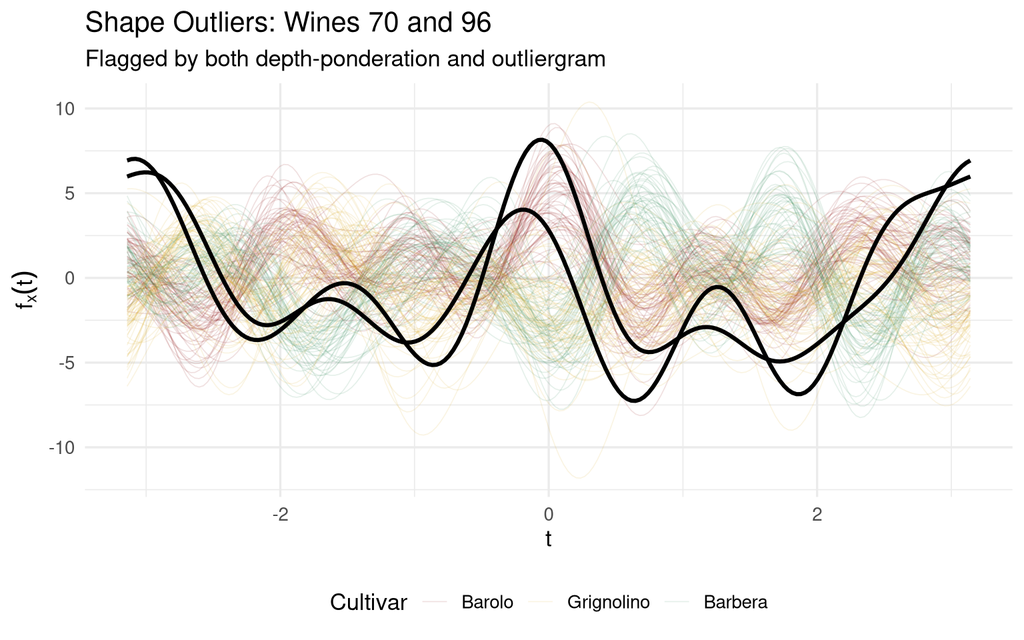

Wines 70 and 96 (black) weave through the Grignolino bundle in an atypical pattern — their shapes cross other cultivars’ territory.

```r
is_shape_case <- rep(FALSE, n)
is_shape_case[shape_cases] <- TRUE

ggplot() +
  geom_line(data = filter(df_curves, !rep(is_shape_case, each = m)),
            aes(x = t, y = value, group = curve, color = Cultivar),
            alpha = 0.12, linewidth = 0.3) +
  geom_line(data = filter(df_curves, rep(is_shape_case, each = m)),
            aes(x = t, y = value, group = curve),
            color = "black", linewidth = 1.1) +
  scale_color_manual(values = c("Barolo" = "#8B0000", "Grignolino" = "#DAA520",
                                 "Barbera" = "#2E8B57")) +
  labs(title = "Shape Outliers: Wines 70 and 96",
       subtitle = "Flagged by both depth-ponderation and outliergram",
       x = expression(t), y = expression(f[x](t))) +
  theme(legend.position = "bottom")
```

Both wines have extremely high Magnesium (151 and 162 mg/L vs a Grignolino average of 94.5). But they also deviate on *different* secondary chemicals — Wine 70 has very low Ash and NonflavPhenols, while Wine 96 has extreme Proanthocyanins (3.3, vs mean 1.6). What makes them *shape* outliers rather than mere magnitude outliers is that this combination of high and low values creates curves that *cross* the normal Grignolino band, dipping below it in some Fourier regions and rising above it in others.

**Quality controller’s action**: investigate the vineyard. Extreme Magnesium in an otherwise Grignolino-like wine suggests a **soil chemistry anomaly** — Magnesium uptake in grapes is strongly influenced by soil composition and rootstock. These wines may come from a plot with unusual mineral content. The shape anomaly means a simple recalibration won’t fix the issue; the underlying growing conditions need review.

### Case Study: Wine 159 — The Lone Barbera Outlier

Wine 159 is the only Barbera flagged, and it’s an outlier for very different reasons than the Grignolinos:

```r
i <- 159
cat(sprintf("Wine %d (%s)\n", i, cultivar[i]))
```

```
Wine 159 (Barbera)
```

```r
cat(sprintf("  Color Intensity: %.1f  (Barbera mean: 7.4, population z = %+.1f)\n",
            wine[i, "ColorIntensity"], X[i, "ColorIntensity"]))
```

```
  Color Intensity: 13.0  (Barbera mean: 7.4, population z = +3.4)
```

```r
cat(sprintf("  Alcohol:         %.1f%%  (Barbera mean: 13.2%%, z = %+.1f)\n",
            wine[i, "Alcohol"], X[i, "Alcohol"]))
```

```
  Alcohol:         14.3%  (Barbera mean: 13.2%, z = +1.6)
```

```r
cat(sprintf("  Phenols:         %.1f  (Barbera mean: 1.7, z = %+.1f)\n",
            wine[i, "Phenols"], X[i, "Phenols"]))
```

```
  Phenols:         2.8  (Barbera mean: 1.7, z = +0.8)
```

```r
cat(sprintf("  Proanthocyanins: %.1f  (Barbera mean: 1.2, z = %+.1f)\n",
            wine[i, "Proanthocyanins"], X[i, "Proanthocyanins"]))
```

```
  Proanthocyanins: 2.7  (Barbera mean: 1.2, z = +1.9)
```

```r
# Within-cultivar rank
cv_idx <- which(cultivar == "Barbera")
fd_cv <- fd_wine[cv_idx]
depths_cv <- depth.MBD(fd_cv)
pos_in_cv <- which(cv_idx == i)
rank_in_cv <- rank(-depths_cv)[pos_in_cv]
cat(sprintf("\n  Depth rank within Barbera: %d / %d (dead last)\n",
            rank_in_cv, length(cv_idx)))
```

```
  Depth rank within Barbera: 48 / 48 (dead last)
```

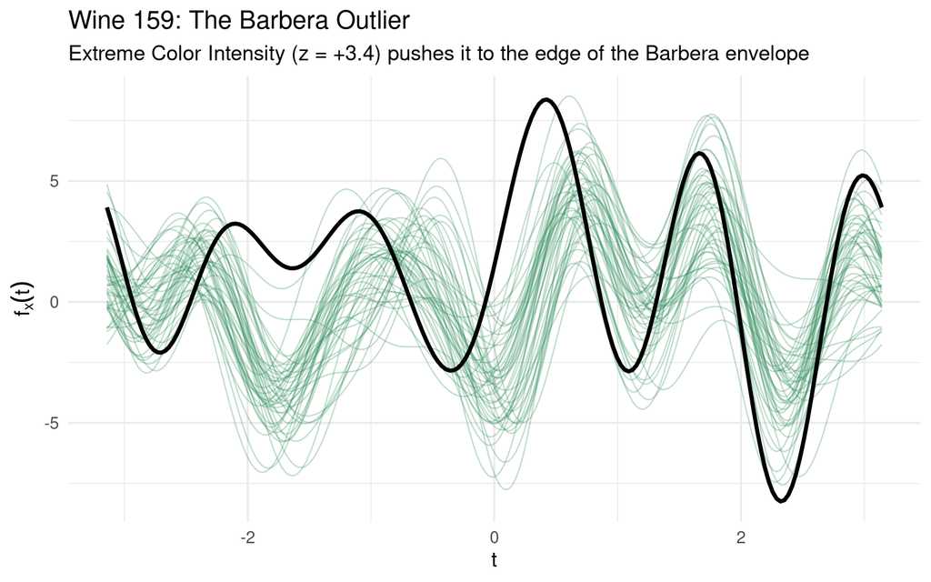

```r
is_159 <- rep(FALSE, n)
is_159[159] <- TRUE

ggplot() +
  geom_line(data = filter(df_curves, Cultivar == "Barbera" & !rep(is_159, each = m)),
            aes(x = t, y = value, group = curve),
            color = "#2E8B57", alpha = 0.3, linewidth = 0.4) +
  geom_line(data = filter(df_curves, rep(is_159, each = m)),
            aes(x = t, y = value, group = curve),
            color = "black", linewidth = 1.2) +
  labs(title = "Wine 159: The Barbera Outlier",
       subtitle = "Extreme Color Intensity (z = +3.4) pushes it to the edge of the Barbera envelope",
       x = expression(t), y = expression(f[x](t)))
```

**Quality controller’s action**: re-test the Color Intensity measurement. A reading of 13.0 is almost double the cultivar mean, which could indicate either a genuinely concentrated wine (late harvest, low yield) or an analytical error. The Phenol and Proanthocyanin values corroborate the “concentrated” hypothesis — they’re consistently elevated, not randomly scattered. If re-testing confirms the values, this wine is likely a natural outlier from an unusually productive or concentrated lot, not a quality defect.